# *Stellar Classification Notebook*

## 6. Semi-supervised Learning Techniques

*Semi-supervised learning* is a machine learning technique that involves training a model using a combination of labeled and unlabeled data. In a supervised learning scenario, the model is trained using a labeled dataset, where the input data is accompanied by its corresponding label or output. In contrast, in an unsupervised learning scenario, the model is only provided with input data and no labels.

*Semi-supervised learning* lies in between these two approaches, as it uses a combination of labeled and unlabeled data to train the model. This is useful in situations where it is expensive or time-consuming to label a large dataset, but a small amount of labeled data is still available.

In this chapter you will see the application of semi-supervised learning techniques like the label propagation and co-training.

Libraries used:

```python
from sklearn.semi_supervised import LabelPropagation
```

### 6.1 Label Propagation

*Label propagation* is a semi-supervised learning technique that involves propagating labels from a small set of labeled data points to a larger set of unlabeled data points in order to classify them. It is based on the idea that data points that are close to each other in the feature space are likely to have similar labels.

In the following code the 90% of labels have been removed to apply the semi supervised technique.

```python
n_labeled = int(len(x_train) * 0.1)
X_train_labeled = x_train[:n_labeled]
y_train_labeled = y_train[:n_labeled]
X_train_unlabeled = x_train[n_labeled:]
```

The data are now prepared for the execution of *label propagation*. In the following box it can be observed that there is the cration of the label propagation model and his fit to the labeled training data. In other words I am using the model to label the unlabeled training data and then combine the labeled and unlabeled data for training.

```python
lp = LabelPropagation(kernel = 'rbf', gamma = 20)
lp.fit(X_train_labeled, y_train_labeled)
y_train_pred = lp.predict(X_train_unlabeled)
X_train_combined = np.concatenate([X_train_labeled, X_train_unlabeled])
y_train_combined = np.concatenate([y_train_labeled, y_train_pred])
```

After the preparation of the model, there is the training of classifiers, in this case the *DecisionTreeClassifier* and the *LogisticRegression*, on the combined labeled and unlabeled data and make prediction on the test set.

```
Accuracy of classifier 1: 0.9296528521180608
Confusion matrix of classifier 1:
```

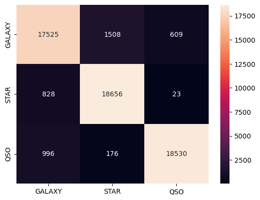

```python
dtc = DecisionTreeClassifier()
dtc.fit(X_train_combined, y_train_combined)
y_test_pred = dtc.predict(x_test)
accuracy = accuracy_score(y_test, y_test_pred)
print('Accuracy of classifier 1:', accuracy)
print('Confusion matrix of classifier 1:')
cm = confusion_matrix(y_test, y_test_pred)
cm_df = pd.DataFrame(cm, index=['GALAXY', 'STAR', 'QSO'], columns=['GALAXY', 'STAR','QSO'])
sns.heatmap(cm_df, annot=True, fmt='d')
```

```
Accuracy of classifier 2: 0.92659428047102
Confusion matrix of classifier 2:
```

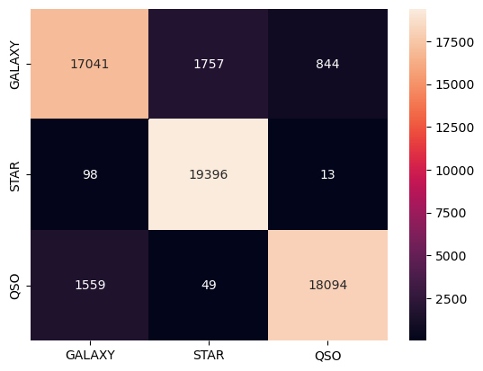

```python
log = LogisticRegression()
log.fit(X_train_combined, y_train_combined)
y_test_pred = log.predict(x_test)
accuracy = accuracy_score(y_test, y_test_pred)
print('Accuracy of classifier 2:', accuracy)
print('Confusion matrix of classifier 2:')
cm = confusion_matrix(y_test, y_test_pred)
cm_df = pd.DataFrame(cm, index=['GALAXY', 'STAR', 'QSO'], columns=['GALAXY', 'STAR','QSO'])
sns.heatmap(cm_df, annot=True, fmt='d')
```

### 6.2 Co-training

*Co-training* is a semi-supervised learning method that involves training two classifiers on different views of the data, and iteratively labeling additional examples using the predictions of the two classifiers. The goal of *co-training* is to improve the performance of the classifiers by leveraging the complementary information present in the different views of the data.

In this case the starting part is related to the split of data into two views; the classifiers are trained on these views using the labeled data. The labeled and unlabeled examples are stored in the lists.

```python
X_view1, X_view2, y_view1, y_view2 = train_test_split(x_train, y_train, test_size=0.5)
ctr1 = RandomForestClassifier()
ctr2 = DecisionTreeClassifier()
ctr1.fit(X_view1, y_view1)
ctr2.fit(X_view2, y_view2)
labeled = [(X_view1, y_view1), (X_view2, y_view2)]
unlabeled = [(x_test, y_test)]
```

The co-training loop then iterates until all examples in unlabeled are labeled or a stopping criteria is met. In each iteration, the classifier trained on one view predicts the labels for the examples in the other view, and these examples are added to the list of labeled examples. The classifiers are then retrained on the newly labeled examples and the stopping criteria is checked.

```python
while len(unlabeled) > 0:
    X_unlabeled, y_unlabeled = unlabeled.pop()
    y_pred = ctr2.predict(X_unlabeled)
    labeled.append((X_unlabeled, y_pred))
    if len(unlabeled) > 0:
      X_unlabeled, y_unlabeled = unlabeled.pop()
      y_pred = ctr1.predict(X_unlabeled)
      labeled.append((X_unlabeled, y_pred))
    X = np.concatenate(X)
    y = np.concatenate(y)
    ctr1.fit(X, y)
    ctr2.fit(X, y)

accuracy1 = ctr1.score(x_test, y_test)
accuracy2 = ctr2.score(x_test, y_test)
```

Finally, the accuracy of the classifier on the test set.

```python
print(f'Accuracy of classifier 1: {accuracy1:.2f}')
print(f'Accuracy of classifier 2: {accuracy2:.2f}')
```

```
Accuracy of classifier 1: 0.98
Accuracy of classifier 2: 0.97
```

Before these results I tried to employ the same classifier for both the views and I obtained the same accuracy; this is not always an error in co-training, but it could indicate that co-training is not providing any benefit over training a single classifier on the full dataset.

Possible reasons why the classifiers have the same accuracy could be that:

- the views of the data are highly correlated, so the classifiers trained on each view are making the same predictions. In this case, the classifiers may be redundant and co-training may not provide any benefit over training a single classifier on the full dataset
- the classifiers are not learning from the labeled examples. This could be due to poor quality or insufficient quantity of labeled examples, or to a problem with the classifiers themselves (such as a lack of capacity or overfitting).

## 7. Comparison with other studies

It could be optimal to compare the outcomes of this project with other studies that can be found on Kaggle on the similar dataset.

Since that the analysis for this dataset is, for most of the times, the same for all the notebooks in Kaggle, I will take the first notebook in term of preferences, and it is the one of Batucan Senkal, accesible via this [link](https://www.kaggle.com/code/psycon/stars-galaxies-eda-and-classification).

The data analysis presents some differences, especially in the outliers detection phase, that in this notebook has been covered. The imbalance detection is the same, and has been handled with the *SMOTE*.

After the data analysis, in the notebook has been covered only the supervised learning phase. In particular, *SVC* *(support vector classification)* and *RandomForest Classifier* have been used. They achieved respectivily, 96.7% and 98.3% of accuracy. Please note that is not present the *cross validation*. There is no grid search phase applied and neither unsupervised and semi-supervised learning.

In this [list](https://www.kaggle.com/datasets/fedesoriano/stellar-classification-dataset-sdss17/code?datasetId=1866141&sortBy=voteCount) you can check other notebooks sorted by preferences received. Unfortunately, it is not possible to make a comparison based on unsupervised and semi-supervised learning due to notebooks and procedures scarcity.